# Group_8_Exploratory_Analysis

# Introduction

Time and time again in the UK we see obesity putting more people’s lives at risk and more pressure on the NHS. Not only does obesity cause majority health complications but it also puts strain on the NHS’s already dwindling budget . So the question arises, is our government doing enough to combat this epidemic?

There is no one solution to cure obesity as many different socio-economic factors play a role in a person’s diet and lifestyle. In the following report we shall investigate the change in the prevalence of obesity in Scotland from 2008-2012. As well as determining if obesity rates are influenced by ages, gender, socio-economic status or other lifestyle factor.

# Exploratory Analysis

Second, we calculated the value of obesity number by year and found each year the population sizes were different. In order to avoid the influence of population size, we calculated the proportion of prevalence of obesity over year and drew a time series plot of obese observations from 2008 to 2012 to show whether the proportion of prevalence of obesity in Scotland changed over the years.

```
[1] 2008 2009 2010 2011 2012
Levels: 2008 2009 2010 2011 2012
```

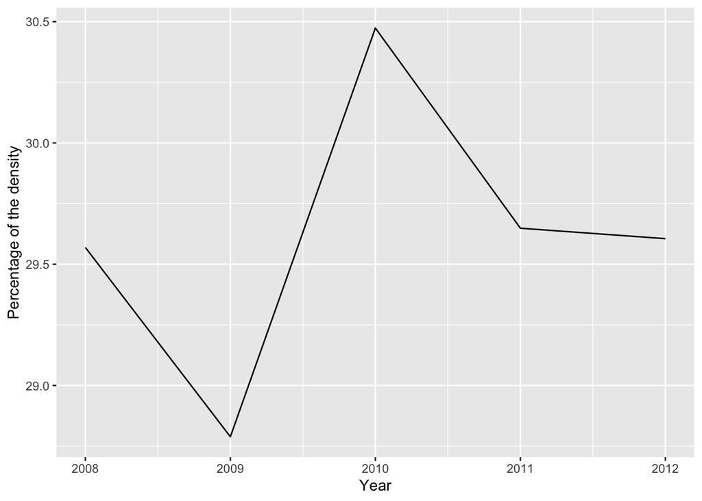

```
# A tibble: 5 × 2
   Year Count_Obese
  <int>       <dbl>
1  2008        1448
2  2009        1647
3  2010        1666
4  2011        1620
5  2012        1088
```

Third, we wanted to explore the distribution of obesity prevalence in each group of different categorical variables. So we made barplot for each categorical variable, which were age, sex and socio-economic status.

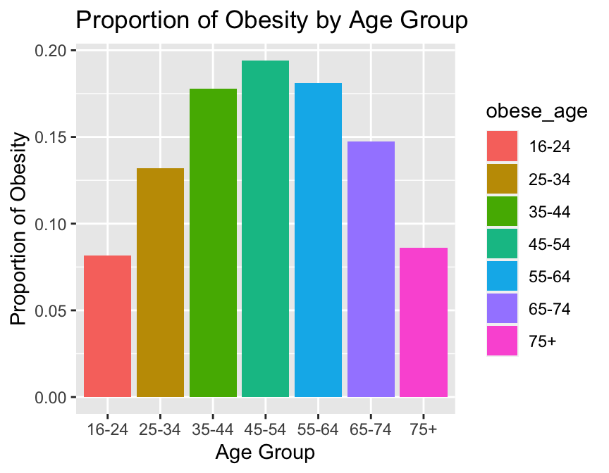

Figure 1: Proportion of obesity by age groups.

Figure 1 displayed the proportion of obesity over each age group. 45-54 group occupied the highest proportion which was nearly 20% . 16-24 and 75+ groups shared the similar proportion which was approximately 8%.

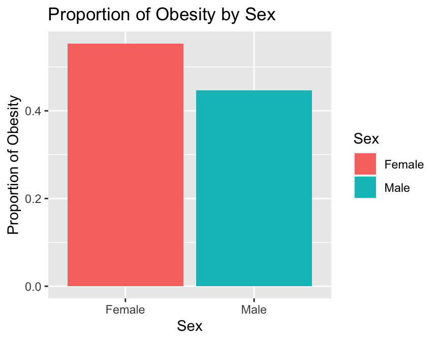

Figure 2: Proportion of Obesity by Sex.

Figure 2 displayed the proportion of obesity over sex. Female occupied higher proportion of obesity which was nearly 55% . Male occupied lower proportion of obesity which was nearly 45%.

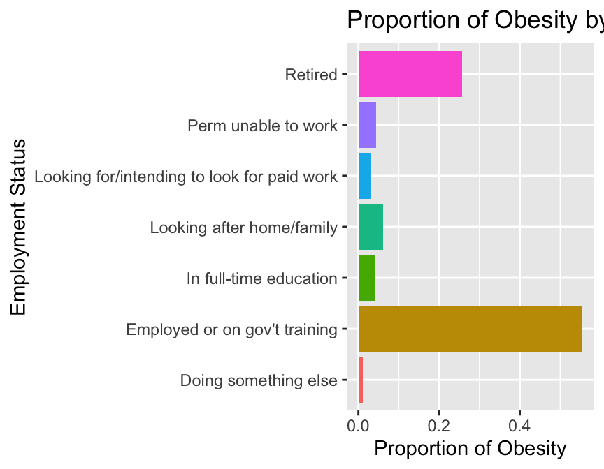

Figure 3: Proportion of Obesity by Employment status.

Figure 3 displayed the proportion of obesity over each socio-economic status. “In paid employment, self-employed or on gov’t training” group occupied the highest proportion which was nearly 55.55% . “Doing something else” occupied the lowest proportion which was approximately 1%.